# Programacion en R

Alfredo Aburto Alcudia: Curso de analisis de datos con Google

2024-01-02

## Introducción

El presente documento tiene como objetivo mostrar las notas realizadas durante la formación de Google como analista de datos junior. Lo anterior, con el fin de fungir como guía de consulta en temas básicos y como última instancia prácticar en la utilización de R markdown para la creación de informes. Ya que anteriormente todas las descripciones teoricas se habian realizado como comentarios sobre archivos de extension “.R”.

## Estructuras de datos en R

Una forma de crear una vector es utilizar la función c() llamada función “combinar” Los vectores atómicos solo pueden contener elementos del mismo tipo.

### Vectores

#### Definición de un vector númerico

```r
vector_01 <- c(2.5,4.9,1.3)
vector_01
```

```
## [1] 2.5 4.9 1.3
```

#### Definición de un vector de números enteros

```r
vector_02 <- c(2L, 3L, 9L)
vector_02
```

```
## [1] 2 3 9
```

#### Definición de un vector de caracteres y valores logicos

```r
vector_03 <- c("Ciencia", "Datos", "Tecnología")
vector_03
```

```
## [1] "Ciencia"    "Datos"      "Tecnología"
```

```r
vector_04 <- c(TRUE, TRUE, FALSE, TRUE, FALSE, FALSE)
vector_04
```

```
## [1]  TRUE  TRUE FALSE  TRUE FALSE FALSE
```

### DETERMINAR PROPIEDADES DE VECTORES (Tipo y longitud)

#### Determinar el tipo de vector con el que se trabaja

```r
typeof(vector_03)
```

```
## [1] "character"
```

#### Verificar si un vector es de un tipo específico usando la función ‘is’

```r
is.logical(vector_02)
```

```
## [1] FALSE
```

```r
is.integer(vector_02)
```

```
## [1] TRUE
```

#### Determinar la longitud del vector

```r
length(vector_04)
```

```
## [1] 6
```

#### Asignación de nombres a los elementos de un vector

Definimos el vector x como ejemplo

```r
x <- c(1, 3, 5)
```

Asignamos nombres a cada elemento del vector x con la función ‘names()’

```r
names(x) <- c("a", "b", "c")
x # Pasamos por consola el vector x
```

```
## a b c
## 1 3 5
```

La asignación de nombres a los elementos de un vector puede ser útil para hacer que el código sea más legible y comprensible, ya que puedes referirte a los elementos por sus nombres en lugar de sus índices. Por ejemplo, para acceder al elemento “c” del vector x

```r
x["c"]
```

```
## c
## 5
```

Con lo anterior enviamos por pantalla al elemento c del vector x

### LISTAS

Las listas difieren de los vectores atómicos porque sus elementos pueden ser de cualquier tipo. Además las listas pueden contener a otras listas.

#### Definición de una lista utilizando la funcion list()

```r
lista_01 <- list("alfredo", 17L, 8.3, FALSE)
lista_01
```

```
## [[1]]
## [1] "alfredo"
##
## [[2]]
## [1] 17
##
## [[3]]
## [1] 8.3
##
## [[4]]
## [1] FALSE
```

#### Definición de listas anidadas

```r
lista_02 <- list(2L, 3.9273, "a", TRUE, list("b", FALSE))
lista_02
```

```
## [[1]]
## [1] 2
##
## [[2]]
## [1] 3.9273
##
## [[3]]
## [1] "a"
##
## [[4]]
## [1] TRUE
##
## [[5]]
## [[5]][[1]]
## [1] "b"
##
## [[5]][[2]]
## [1] FALSE
```

#### Determinar la estructura de una lista

Si se desea saber qué tipos de elementos contiene una lista, puedes utilizar la función str().

```r
str(lista_02)
```

```
## List of 5
##  $ : int 2
##  $ : num 3.93
##  $ : chr "a"
##  $ : logi TRUE
##  $ :List of 2
##   ..$ : chr "b"
##   ..$ : logi FALSE
```

Al ejecutar la función str(), R mostrará la estructura de datos de la lista mediante la descripción de sus elementos y tipos

#### Nombrando los elementos de una lista

Al igual que con los vectores, podemos nombrar los elementos de una lista, asignandole a cada elemento un nombre cuando definimos la lista.

```r
lista_03 = list('Temperatura (K)' = 20.5, "Presion (atm)" = 1L)
lista_03 # Enviamos por pantalla lista_03
```

```
## $`Temperatura (K)`
## [1] 20.5
##
## $`Presion (atm)`
## [1] 1
```

## Fechas y horas

Para trabajar con fechas y horas utilizammos el paqute lubridate. Para ello es necesario instalar y cargar los paquetes tidyverse y lubridate el cual es parte de tidyverse - Instalacion de paquete tydyverse

```r
install.packages("tidyverse")
```

- Carga de paquetes tidyverse y lubridate utilizando la función ‘library()’

```r
library(tidyverse)
```

Lubridate es un paquete diseñado para trabajar con fechas y horas de una manera más sencilla y cómoda. Algunas de las funciones y características clave incluyen: - Parseo de fechas: Facilita la conversión de texto a objetos de fecha y hora. - Manipulación de fechas: Proporciona funciones para extraer y manipular componentes de fechas, como días, meses, años, horas y minutos. - Operaciones con fechas: Permite realizar cálculos y operaciones entre fechas de manera intuitiva. - Manejo de zonas horarias: Facilita el trabajo con zonas horarias y la conversión entre ellas.

### Trabajando con fechas y horas

#### Tipos

En R hay tres tipos de datos que hacen referencia a un instante en el tiempo - Fecha: (“2002-10-17”) - Hora de un dia: (“23:54:46 UTC”) - Fecha-hora: (“2010-04-25 16:12:05 UTC”)

La hora se expresa en UTC, que quiere decir Hora Universal Coordinada, más comúnmente conocida como tiempo civil. Este es el estándar principal que regula los relojes y la hora mundial.

Obtener la fecha actual (mes, año, día)

```r
today()
```

```
## [1] "2024-01-02"
```

Obtener fecha y hora actual

```r
now()
```

```
## [1] "2024-01-02 18:10:32 CST"
```

Al trabajar con R, hay tres modos posibles de crear formatos de fecha-hora: - Desde una cadena - Desde una fecha individual - Desde un objeto de fecha/hora existente

R crea fechas en el formato estándar yyyy-mm-dd (año-mes-día) por defecto.

#### Convertir a partir de una cadena

Los datos de fecha/hora a menudo se expresan como cadenas. Puedes convertir cadenas en fechas y fecha-hora utilizando las herramientas provistas por lubridate. Estas herramientas automáticamente trabajan sobre el formato de fecha/hora.

1. Primero, identifica el orden en el año, el mes y el día que aparecen en tus fechas.
2. Ordena las letras y, m y d (año, mes y día) en el mismo orden. Eso te dará el nombre de la función lubridate que analizará tu fecha.

Por ejemplo, para la fecha 2021-01-20, utilizarás el orden ymd:

```r
fecha_01 <- ymd("2021-01-20")
fecha_01 # Enviamos por pantalla fecha_01
```

```
## [1] "2021-01-20"
```

mdy Febrero 20th, 2023

```r
fecha_02 <- mdy("Febrero 20th, 2023")
fecha_02
```

```
## [1] "2023-02-20"
```

Estas funciones también toman números que no están entre comillas y los convierte al formato yyyy-mm-yy.

```r
fecha_03 <- ymd(20210120)
fecha_03
```

```
## [1] "2021-01-20"
```

#### Crear componentes de fecha-hora

La función ymd() y sus variantes crean fechas. Para crear una fecha-hora desde una fecha, agrega un guion bajo y una o más de las letras h, m y s (horas, minutos y segundos) al nombre de la función:

```r
fecha_04 <- ymd_hms("2021-01-20 20:11:59")
fecha_04
```

```
## [1] "2021-01-20 20:11:59 UTC"
```

Notar el orden en el que se ponen las letras en la función

```r
fecha_05 <- ymd_hms("2021-01-20 20:11:59")
fecha_05
```

```
## [1] "2021-01-20 20:11:59 UTC"
```

#### Cambiar entre objetos existentes de fecha-hora

Quizas se quiera cambiar entre una fecha-hora y una fecha. Se puede utilizar la función as_date() para convertir una fecha-hora en una fecha.

```r
fecha_06 <- as_date(now())
fecha_06
```

```
## [1] "2024-01-02"
```

## Organizar datos

Si nuestra información no esta ordenada no podemos transformar la información en conocimiento. Ordenar nuestros datos nos permite conocer nuevos detalles de nuestros datos.

Para lograrlo utilizaremos las funciones: - arrange() - group_by() - filter()

1. Inserta el paquete tidyverse para poder utilizar su núcleo
2. Obtención de conjunto de datos

```r
install.packages("palmerpenguins")
```

3. Cargamos nuestros datos

```r
library(palmerpenguins)
```

**Ordenar datos por una columna especifica en este caso longitud de su pico**

Los siguientes comandos crean un **tibble** y es importante recordar que estos comandos NO modifican mi conjunto de datos, solo estan temporalmente por pantalla

```r
penguins %>% arrange(bill_length_mm) # Ordena ascendentemente
```

| species | island | bill_length_mm | bill_depth_mm | flipper_length_mm | body_mass_g | sex | year |
| --- | --- | --- | --- | --- | --- | --- | --- |
| Adelie | Dream | 32.1 | 15.5 | 188 | 3050 | female | 2009 |
| Adelie | Dream | 33.1 | 16.1 | 178 | 2900 | female | 2008 |
| Adelie | Torgersen | 33.5 | 19.0 | 190 | 3600 | female | 2008 |
| Adelie | Dream | 34.0 | 17.1 | 185 | 3400 | female | 2008 |
| Adelie | Torgersen | 34.1 | 18.1 | 193 | 3475 | NA | 2007 |
| Adelie | Torgersen | 34.4 | 18.4 | 184 | 3325 | female | 2007 |
| Adelie | Biscoe | 34.5 | 18.1 | 187 | 2900 | female | 2008 |
| Adelie | Torgersen | 34.6 | 21.1 | 198 | 4400 | male | 2007 |
| Adelie | Torgersen | 34.6 | 17.2 | 189 | 3200 | female | 2008 |
| Adelie | Biscoe | 35.0 | 17.9 | 190 | 3450 | female | 2008 |

[output cut: 334 more lines]

```r
penguins %>% arrange(-bill_length_mm) # Ordena descendente añandiendo "-"
```

| species | island | bill_length_mm | bill_depth_mm | flipper_length_mm | body_mass_g | sex | year |
| --- | --- | --- | --- | --- | --- | --- | --- |
| Gentoo | Biscoe | 59.6 | 17.0 | 230 | 6050 | male | 2007 |
| Chinstrap | Dream | 58.0 | 17.8 | 181 | 3700 | female | 2007 |
| Gentoo | Biscoe | 55.9 | 17.0 | 228 | 5600 | male | 2009 |
| Chinstrap | Dream | 55.8 | 19.8 | 207 | 4000 | male | 2009 |
| Gentoo | Biscoe | 55.1 | 16.0 | 230 | 5850 | male | 2009 |
| Gentoo | Biscoe | 54.3 | 15.7 | 231 | 5650 | male | 2008 |
| Chinstrap | Dream | 54.2 | 20.8 | 201 | 4300 | male | 2008 |
| Chinstrap | Dream | 53.5 | 19.9 | 205 | 4500 | male | 2008 |
| Gentoo | Biscoe | 53.4 | 15.8 | 219 | 5500 | male | 2009 |
| Chinstrap | Dream | 52.8 | 20.0 | 205 | 4550 | male | 2008 |

[output cut: 334 more lines]

Si deseamos crear un nuevo marco de datos que contenga los datos ordentados seguiremos el siguiente ejemplo, con él logramos guardar datos limpios sin perder infromación del conjunto de datos original

```r
penguins_bill_descen <- penguins %>% arrange(-bill_length_mm)
View(penguins_bill_descen)
```

### group_by()

Esta función suele combinarse con otras funciones, nos permite agrupar por alguna columna en particular y luego realizar una operación esos grupos

- Creamos nuestro grupo

```r
penguins %>%
  group_by(island) %>% # Agrupamos por isla
  drop_na() %>% # Eliminamos filas con valores nulos en cualquier columna
  summarise(mean_bill_length_mm = mean(bill_length_mm))
```

| island | mean_bill_length_mm |
| --- | --- |
| Biscoe | 45.24847 |
| Dream | 44.22195 |
| Torgersen | 39.03830 |

En el fragmento anterior la función summarise se utiliza para resumir los datos dentro de cada grupo, en este caso, calculando la media de una columna especifica.

Otro ejemplo de uso

```r
penguins %>%
  group_by(island) %>%
  drop_na() %>%
  summarise(max_bill_length_mm = max(bill_length_mm))
```

| island | max_bill_length_mm |
| --- | --- |
| Biscoe | 59.6 |
| Dream | 58.0 |
| Torgersen | 46.0 |

Podemos utilizar tanto group_by como summarise para realizar los dos ejemplos anteriores simultasneamente:

```r
penguins %>%
  group_by(species, island) %>%
  drop_na() %>%
  summarise(max_bl = max(bill_length_mm), mean_bl = mean(bill_length_mm))
```

| species | island | max_bl | mean_bl |
| --- | --- | --- | --- |
| Adelie | Biscoe | 45.6 | 38.97500 |
| Adelie | Dream | 44.1 | 38.52000 |
| Adelie | Torgersen | 46.0 | 39.03830 |
| Chinstrap | Dream | 58.0 | 48.83382 |
| Gentoo | Biscoe | 59.6 | 47.56807 |

El fragmento anterior logra realizar varias tareas de limpieza gracias al uso de la canalización o pipes, el resultados es un conjunto de datos que muestra la longitud máxima del pico y el promedio de la longitud del pico por especie que se encuentra en cada isla.

### filter()

Supongamos que deseamos obtener solo los datos sobre los pinguinos Adelie.

```r
penguins %>%
  filter(species == "Adelie") # Exactamente igual a la especia Adelie
```

| species | island | bill_length_mm | bill_depth_mm | flipper_length_mm | body_mass_g | sex | year |
| --- | --- | --- | --- | --- | --- | --- | --- |
| Adelie | Torgersen | 39.1 | 18.7 | 181 | 3750 | male | 2007 |
| Adelie | Torgersen | 39.5 | 17.4 | 186 | 3800 | female | 2007 |
| Adelie | Torgersen | 40.3 | 18.0 | 195 | 3250 | female | 2007 |
| Adelie | Torgersen | NA | NA | NA | NA | NA | 2007 |
| Adelie | Torgersen | 36.7 | 19.3 | 193 | 3450 | female | 2007 |
| Adelie | Torgersen | 39.3 | 20.6 | 190 | 3650 | male | 2007 |
| Adelie | Torgersen | 38.9 | 17.8 | 181 | 3625 | female | 2007 |
| Adelie | Torgersen | 39.2 | 19.6 | 195 | 4675 | male | 2007 |
| Adelie | Torgersen | 34.1 | 18.1 | 193 | 3475 | NA | 2007 |
| Adelie | Torgersen | 42.0 | 20.2 | 190 | 4250 | NA | 2007 |

[output cut: 142 more lines]

## Transformación de Datos

A veces necesitamos dividir una variable entre múltiples columnas o combinar las columnas atuales, o incluso agregar nuevos valores a el marco de datos. Las funciones básicas incluyen:

- separate()
- unite()
- mutate()

**Creamos un marco de datos desde cero**

```r
id <- c(1:10)
name <- c("John Mendes", "Rob Stewart", "Rachel Abrahamson", "Christy Hickman",
          "Johnson Harper", "Candace Miller", "Carlson Landy", "Pansy Jordan",
          "Darius Berry", "Claudia Garcia")

job_title <- c("Professional", "Programmer", "Management", "Clerical", "Developer",
               "Programmer", "Management", "Clerical", "Developer", "Programmer")

employee <- data.frame(id, name, job_title)

print(employee)
```

```
##    id              name    job_title
## 1   1       John Mendes Professional
## 2   2       Rob Stewart   Programmer
## 3   3 Rachel Abrahamson   Management
## 4   4   Christy Hickman     Clerical
## 5   5    Johnson Harper    Developer
## 6   6    Candace Miller   Programmer
## 7   7     Carlson Landy   Management
## 8   8      Pansy Jordan     Clerical
## 9   9      Darius Berry    Developer
## 10 10    Claudia Garcia   Programmer
```

### separate()

Permite separar datos de un data frame de una columna en especifico con algun separador que podamos encontrar por ejemplo un espacio

```r
employee_separate <- separate(employee, name, into=c("first_name", "last_name"), sep=" ")
employee_separate
```

| id | first_name | last_name | job_title |
| --- | --- | --- | --- |
| 1 | John | Mendes | Professional |
| 2 | Rob | Stewart | Programmer |
| 3 | Rachel | Abrahamson | Management |
| 4 | Christy | Hickman | Clerical |
| 5 | Johnson | Harper | Developer |
| 6 | Candace | Miller | Programmer |
| 7 | Carlson | Landy | Management |
| 8 | Pansy | Jordan | Clerical |
| 9 | Darius | Berry | Developer |
| 10 | Claudia | Garcia | Programmer |

Con la función anterior decimos “del data-frame employee en la columna name separa el contenido de cada fila en dos columnas, el primer elemento de la separación lo colocas en la columna”first_name” y el segundo elemento en la columna “last_name”, para encontrar cada elemento debes buscar un espacio en blanco como caracter de separacion.

La función separate tiene un aliado, la función unite.

### unite()

Esta función nos permite fusionar columnas entre sí, es decir, lo opuesto a la funcion separate.

**Trabajando con el data.frame con dos columnas de nombre**

```r
unite(employee_separate, 'name', first_name, last_name, sep=" ")
```

| id | name | job_title |
| --- | --- | --- |
| 1 | John Mendes | Professional |
| 2 | Rob Stewart | Programmer |
| 3 | Rachel Abrahamson | Management |
| 4 | Christy Hickman | Clerical |
| 5 | Johnson Harper | Developer |
| 6 | Candace Miller | Programmer |
| 7 | Carlson Landy | Management |
| 8 | Pansy Jordan | Clerical |
| 9 | Darius Berry | Developer |
| 10 | Claudia Garcia | Programmer |

Con la funcion anterior decimos “Usa el data frame employee_separate, nombra la columna donde se juntaran las columnas como ‘name, une las columnas ’first_name’, y ‘last_name’ y separalos con un espacio”

### mutate()

La función mutate()permite agregar una columna de datos es decir una nueva variable.

```r
install.packages("palmerpenguins")
library(palmerpenguins)
data('penguins')
View(penguins)
```

En este dataset, la masa de los pinguinos se encuentra en gramos. Por lo que crearemos una nueva columna con la masa corporal en kg

```r
penguins %>%
  mutate(body_mass_kg = body_mass_g/1000, flipper_length_m=flipper_length_mm/1000)
```

| species | island | bill_length_mm | bill_depth_mm | flipper_length_mm | body_mass_g | sex | year | body_mass_kg | flipper_length_m |
| --- | --- | --- | --- | --- | --- | --- | --- | --- | --- |
| Adelie | Torgersen | 39.1 | 18.7 | 181 | 3750 | male | 2007 | 3.750 | 0.181 |
| Adelie | Torgersen | 39.5 | 17.4 | 186 | 3800 | female | 2007 | 3.800 | 0.186 |
| Adelie | Torgersen | 40.3 | 18.0 | 195 | 3250 | female | 2007 | 3.250 | 0.195 |
| Adelie | Torgersen | NA | NA | NA | NA | NA | 2007 | NA | NA |
| Adelie | Torgersen | 36.7 | 19.3 | 193 | 3450 | female | 2007 | 3.450 | 0.193 |
| Adelie | Torgersen | 39.3 | 20.6 | 190 | 3650 | male | 2007 | 3.650 | 0.190 |
| Adelie | Torgersen | 38.9 | 17.8 | 181 | 3625 | female | 2007 | 3.625 | 0.181 |
| Adelie | Torgersen | 39.2 | 19.6 | 195 | 4675 | male | 2007 | 4.675 | 0.195 |
| Adelie | Torgersen | 34.1 | 18.1 | 193 | 3475 | NA | 2007 | 3.475 | 0.193 |
| Adelie | Torgersen | 42.0 | 20.2 | 190 | 4250 | NA | 2007 | 4.250 | 0.190 |

[output cut: 334 more lines]

### Mismos datos diferentes resultados

Instalamos el paquete donde se encuentra el data set sobre el cuarteto de Anscombe

```r
install.packages('Tmisc')
```

Cargamos los datos

```r
library(Tmisc)
data(quartet)
View(quartet)
```

Este conjunto de datos contiene 4 conjuntos de ejex x e y. Los datos se pueden resumir a través de diferentes parametros estadisticos. Obtendremos un resumen de cada conjunto de datos con la media, desvest y la correalacion.

Cargamos paquetes necesarios para usar summarize

```r
install.packages("dplyr")
library(dplyr)
```

```r
quartet %>%
  group_by(set) %>%
  summarize(mean(x), sd(x), mean(y), sd(y), cor(x, y))
```

| set | mean(x) | sd(x) | mean(y) | sd(y) | cor(x, y) |
| --- | --- | --- | --- | --- | --- |
| I | 9 | 3.316625 | 7.500909 | 2.031568 | 0.8164205 |
| II | 9 | 3.316625 | 7.500909 | 2.031657 | 0.8162365 |
| III | 9 | 3.316625 | 7.500000 | 2.030424 | 0.8162867 |
| IV | 9 | 3.316625 | 7.500909 | 2.030579 | 0.8165214 |

Al observar la salida del comando anterior podemos ver que tanto la media, como la desviacion estandar y la correlacion entre las variables x e y en cada cuadrante es identica. Pero mirar unicamente el resumen estadistico puede resultar engañoso. Para notar esto, creaeremos algunos gráficos:

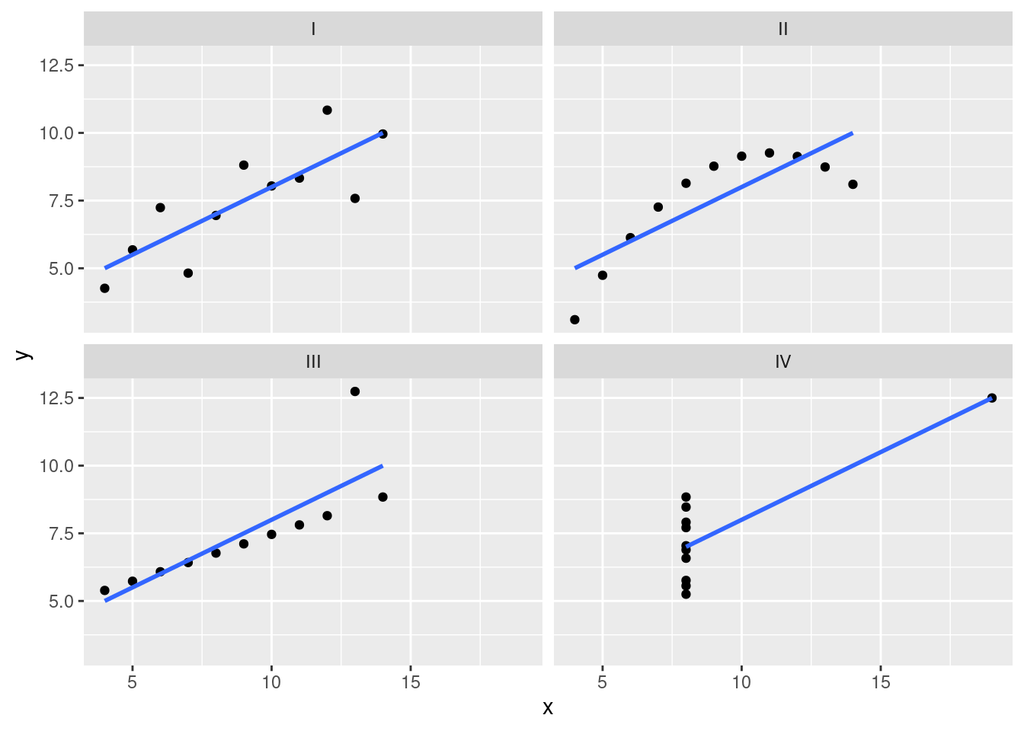

```r
ggplot(quartet,aes(x,y)) + geom_point() + geom_smooth(method=lm, se=FALSE) +
  facet_wrap(~set)
```

Los gráficos generados muestran las grandes diferencias que hay para cada cuadrante

### Función de sesgo

En R podemos cuantificar el sesgo comparando el resultado real de nuestros datos con el resultado previsto. Existe explicacion estadistica detras de lo mencionado anteriormente, sin embargo, con la funcion bias no es necesario hacer el cálculo en forma manual.

#### bias()

La función bias calcula el promedio en que el resultado real supera al resultado previsto. Está incuido en el paqueto de diseño Sim.

Si el modelo no tiene sesgo, el resultado debería ser bastante cercano a cero. Un resultado alto significa que tus datos podrían estar sesgados.

- Instalando y cargando el paquete

```r
install.packages("SimDesign")
library(SimDesign)
```

Usaremos la función bias para comparar las temperaturas pronosticadas con las temperaturas reales.

- Tomando una muestra del conjunto de datos de temperatura

```r
actual_temp <- c(68.3, 70, 72.4, 71, 67, 70)
predicted_temp <- c(67.9, 69, 71.5, 70, 67, 69)
```

- Usando bias

```r
bias_01 = bias(actual_temp, predicted_temp)
bias_01
```

```
## [1] 0.7166667
```

- Otro escenario

Trabajaremos para una tienda de juegos, la tienda viene llevando un registro de cuantas copias de juegos nuevos venden en la fecha de lanzamiento. Quieren comparar estas cifras con sus ventas reales para saber si los pedidos de stock oinciden con sus necesidades reales

```r
actual_sales <- c(150, 203, 137, 247, 116, 287)
predicted_sales <- c(200, 300, 150, 250, 150, 300)

bias_02 <- bias(actual_sales, predicted_sales)
bias_02
```

```
## [1] -35
```

Si el resultado del bias es **positivo** significa que estamos por abajo de lo pronosticado. Por el contrario, un resultado **negativo** indica que estamos por arriba del pronostico. En nuestro ultimo escenario, significaria que estamos pidiendo demasiado stock para las fechas de lanzamiento.

El sesgo se refiere a la tendencia sistemática de los errores, es decir, si las predicciones tienden a ser sistemáticamente más altas o más bajas que los valores reales.

### Visualizacion de datos

En R existen multiples paquetes que permiten crear visualizacion de datos. Plotly te permite realizar una gran variedad de funciones de visualización, por otro lado, RGL se enfoca en soluciones específicas como visualizaciones 3D.

Algunos de los paquetes más populares incluyen: - ggplot2 - Plotly - Lattice - RGL - Dygraphs - Leaflet - Highcharter - Patchwork, - gganimate y ggridges.

#### ggplot2

Creado por el estadístico y desarrolador Hadley Wickham en 2005, inspirado por el libro “The Grammar of Graphics”, un estudio académico sobre la visualizacion de datos, escrito por el cientifico de la computación Leland Wilkinson.

De igual forma que los humanos usamos la gramatica para establecer normas para crear oraciones, la gramática de los gráficos nos da normas para armar cualquier tipo de visualización.

ggplot2 tiene algunos bloques de constricción básicos que puedes usar para crear diagramas. Cuando tenemos claros estos bloques de consturccion básicos podemos usarlos para crear muchos tipos de diagramas diferentes. Además, puedes agregar o quitar capas de detalles a tu diatrama sin cambiar su estructura básica o los datos subyacentes.

Puedes crear todo tipo de diagramas diferentes, entre ellos, diagramas de dispersión, gráficos de barras, diagramas de línea, y muchos más.

Puedes cambiar los colores, el diseño y las dimensiones de tus diagramas y gregar elementos de texto como títulos, leyendas y etiquetas. Con solo un poco de código puedes crear representaciones visuales de alta calidad.

Además, ggplot2 te deja combinar manipulación y visualización de datos usando el operador de canalización. Ggplot2 también tiene muchísimas funciones que satisfacen todas tus necesidades de visualización de datos.

Nos enfocaremos en algunos conceptos centrales en ggplot2: - estética - figuras geométricas - facetas - etiquetas y anotaciones.

#### Estética

La estética incluye cosas como el tamaño, la forma y el color de tus puntos de datos. Piensa en una estética como una conexión o mapeo entre una característica visual en tu diagrama y una variable en tus datos.

#### Figuras geométricas

Una figura geométrica se refiere al objeto geométrico usado para representar tus datos. Por ejemplo, puedes usar puntos para crear un diagrama de dispersión, barras para crear un gráfico de barras o líneas para crear un diagrama de líneas. Puedes elegir una figura geométrica que se adapte al tipo de datos que tienes. Los puntos muestran la relación entre dos variables cuantitativas. Las barras muestran una variable cuantitativa que varía entre diferentes categorías.

#### Facetas

Las facetas te permiten mostrar grupos más pequeños, o subconjuntos, de datos. Con las facetas, puedes crear diagramas separados para todas las variables en tu conjunto de datos.

#### Funciones label y annotate

Por último, las funciones label y annotate te dejan personalizar tu diagrama. Puedes agregar texto como títulos, subtítulos y leyendas para comunicar el propósito de tu diagrama o destacar datos importantes.